# HW-03

Elyse Adamic

25/09/2019

The first three tasks I did completely (for marks), the last two I did parts as extra.

For each task, produce 1) a tibble 2) a visualization tool 3) dialogue.

### Task 3

Look at the spread of GDP per capita within continent.

```r
gapminder %>%
  group_by(continent) %>%
  summarize(min = min(gdpPercap), mean = mean(gdpPercap), med = median(gdpPercap), max = max(gdpPercap), sd = sd(gdpPercap))
```

```
## # A tibble: 5 x 6
##   continent    min   mean    med     max     sd
##   <fct>      <dbl>  <dbl>  <dbl>   <dbl>  <dbl>
## 1 Africa      241.  2194.  1192.  21951.  2828.
## 2 Americas   1202.  7136.  5466.  42952.  6397.
## 3 Asia        331   7902.  2647. 113523. 14045.
## 4 Europe      974. 14469. 12082.  49357.  9355.
## 5 Oceania   10040. 18622. 17983.  34435.  6359.
```

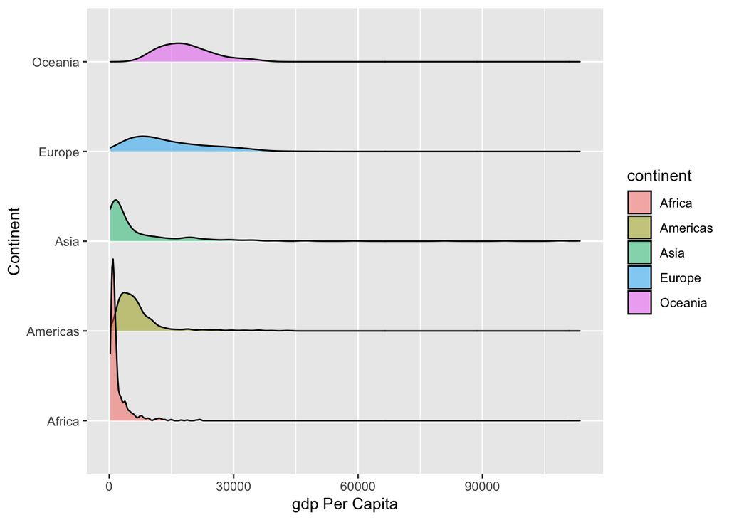

```r
ggplot(gapminder, aes(gdpPercap, continent, height= ..density.., fill = continent)) +
  ggridges::geom_density_ridges(stat = "density", alpha = 0.5) +
  ylab("Continent") +
  xlab("gdp Per Capita")
```

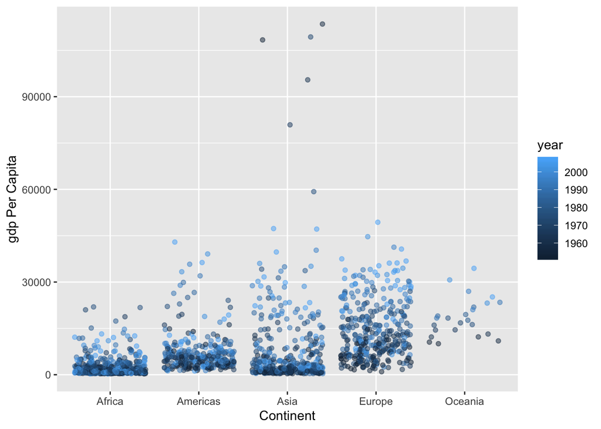

```r
ggplot(gapminder, aes(continent, gdpPercap, color = year)) +
  geom_jitter(alpha = 0.5) +
  xlab("Continent") +
  ylab("gdp Per Capita")
```

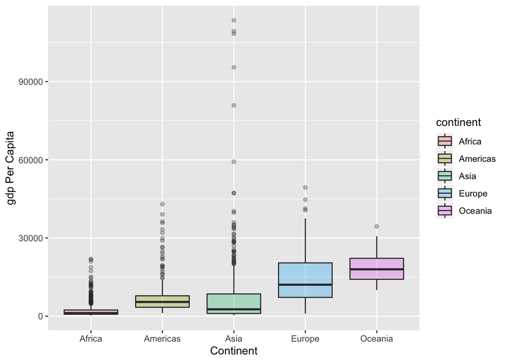

```r
ggplot(gapminder, aes(x=continent, y=gdpPercap)) +
  geom_boxplot(aes(fill = continent), alpha = 0.3) +
    xlab("Continent") +
    ylab("gdp Per Capita")
```

Here are three different demonstrations of the spread of GDP per capita wihtin the continents. Note I interpreted this as all years altogether. The tibble displays some summary statistics to compare between continents, however the distributions are best displayed visually. From the density ridges, clearly Africa has high bunching of low GDP per Capitas and Oceania has the highest mean. The jitter plot is perhaps most useful to see the outliers of Asia. It is also clear how few observations Oceania has. The box plot shows that European values are least bunched. Again, Asia has some extreme outliers and clearly has the highest maximum.

### Task 4

Compute a trimmed or a weighted mean of life expectancy for each year.

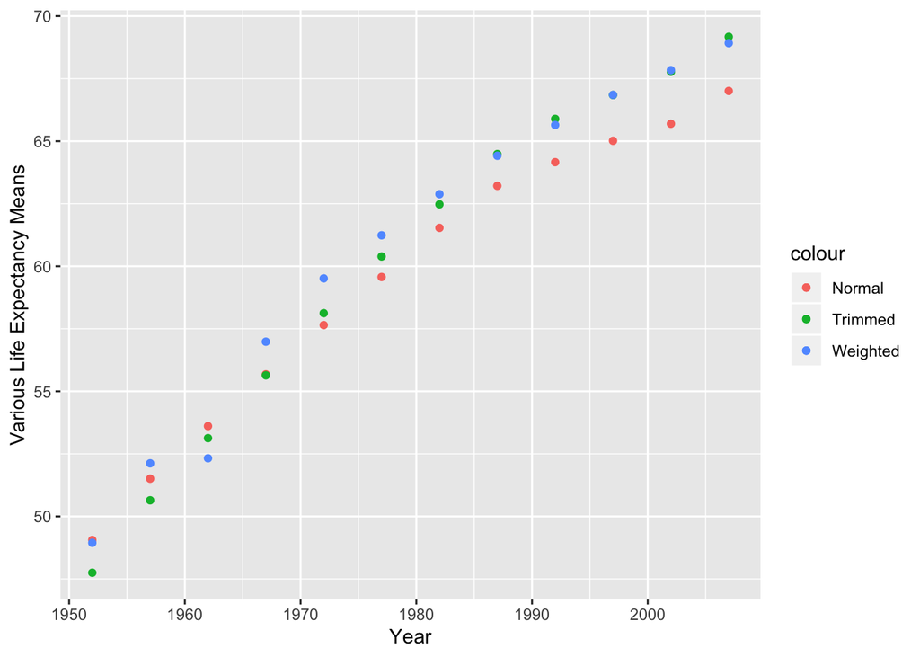

```r
gap_means <-gapminder %>%
  group_by(year) %>%
  summarise(normal = mean(lifeExp),
            trimmed = mean(lifeExp, trim = 0.2),
            weighted = sum(lifeExp*pop)/sum(pop))

# VISUALIZE
#horizontal bar

ggplot(gap_means,aes(year)) +
  geom_point(aes(y = normal, color = "Normal")) +
  geom_point(aes(y = trimmed, color = "Trimmed")) +
  geom_point(aes(y = weighted, color = "Weighted"))+
  xlab("Year") +
  ylab("Various Life Expectancy Means")
```

Here the three means are plotted for each year. There is a clear upward trend in global mean life expectancy over time, regardless of the type of mean calculation. It seems the normal mean is flattest, and the weighted and trimmed means rise sharper. All three measures are relatively similar.

### Task 5

Life expectancy over time on different contients.

```r
gapminder %>%
  group_by(continent, year) %>%
  summarise(mean = mean(lifeExp))
```

```
## # A tibble: 60 x 3
## # Groups:   continent [5]
##    continent  year  mean
##    <fct>     <int> <dbl>
##  1 Africa     1952  39.1
##  2 Africa     1957  41.3
##  3 Africa     1962  43.3
##  4 Africa     1967  45.3
##  5 Africa     1972  47.5
##  6 Africa     1977  49.6
##  7 Africa     1982  51.6
##  8 Africa     1987  53.3
##  9 Africa     1992  53.6
## 10 Africa     1997  53.6
## # … with 50 more rows
```

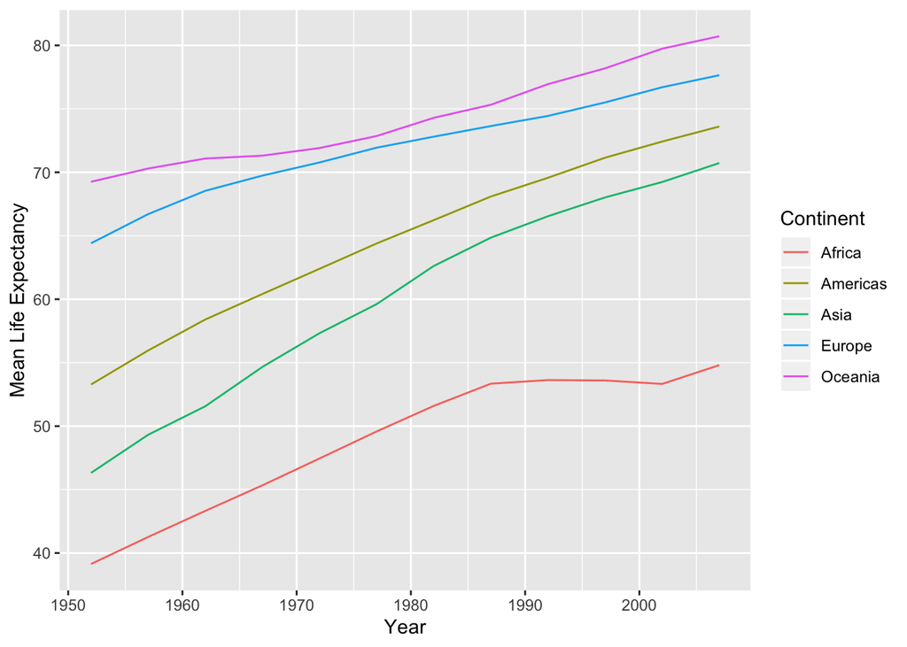

```r
gapminder %>%
  group_by(continent, year) %>%
  mutate(mean_lifeExp = mean(lifeExp)) %>%
  ggplot(aes(year,mean_lifeExp, color = continent)) +
  geom_line(aes(group = continent)) +
  ylab("Mean Life Expectancy" ) +
  xlab("Year") +
  scale_color_discrete("Continent")
```

This line graph also shows the upward trend in life expectancy over time for each continent. Note this is just the mean, alternatively it would be interesting to look at how the minimum or maximum observed life expectancy within a continent changes over time. This graph shows that rank is preserved, Oceania is always the highest and Africa is always the lowest. Essentially all countries experience constant increases, except Africa goes through a stagnant period in the 90s.

The following were done as optional exercises:

### Task 1

Create a benchmark life expectancy for each year. How many countries wtihin each continent are below this benchmark each year?

```r
# A benchmark: 25th quantile
gapminder %>%
  group_by(continent, year) %>% #5 continents x 12 years = 60 groups
  summarize(n = sum(ifelse(lifeExp < quantile(gapminder$lifeExp, c(.25)),1,0)))
```

```
## # A tibble: 60 x 3
## # Groups:   continent [5]
##    continent  year     n
##    <fct>     <int> <dbl>
##  1 Africa     1952    49
##  2 Africa     1957    47
##  3 Africa     1962    42
##  4 Africa     1967    37
##  5 Africa     1972    28
##  6 Africa     1977    24
##  7 Africa     1982    19
##  8 Africa     1987    16
##  9 Africa     1992    14
## 10 Africa     1997    16
## # … with 50 more rows
```

### Task 2

Calculate the min and max GDP per capita for all continents.

```r
# This code displays the country of the maximum and minimum
gapminder %>%
  group_by(continent) %>%
  summarize(max = max(gdpPercap), min = min(gdpPercap),
            country_min = country[gdpPercap == min], country_max = country[gdpPercap == max])
```

```
## # A tibble: 5 x 5
##   continent     max    min country_min            country_max
##   <fct>       <dbl>  <dbl> <fct>                  <fct>
## 1 Africa     21951.   241. Congo, Dem. Rep.       Libya
## 2 Americas   42952.  1202. Haiti                  United States
## 3 Asia      113523.   331  Myanmar                Kuwait
## 4 Europe     49357.   974. Bosnia and Herzegovina Norway
## 5 Oceania    34435. 10040. Australia              Australia
```

```r
# This is another way to list the country, I just filtered on minimum here.
gapminder %>%
  group_by(continent) %>%
  mutate(max = max(gdpPercap), min = min(gdpPercap)) %>%
  filter (gdpPercap == min) %>%
  arrange (min) %>%
  select (continent, country, year, min)
```

```
## # A tibble: 5 x 4
## # Groups:   continent [5]
##   continent country                 year    min
##   <fct>     <fct>                  <int>  <dbl>
## 1 Africa    Congo, Dem. Rep.        2002   241.
## 2 Asia      Myanmar                 1952   331
## 3 Europe    Bosnia and Herzegovina  1952   974.
## 4 Americas  Haiti                   2007  1202.
## 5 Oceania   Australia               1952 10040.
```

```r
# Recall that ggplot will ignore groupings!
```